# Научная презентация

Дисциплина:Операционные системы

Абрамова У. М.

Российский университет дружбы народов, Москва, Россия

Математический институт имени Никольского, Москва, Россия

21.03.2025

# Информация

## Докладчик

- Абрамова Ульяна Михайловна
- Студент НММбд-01-24
- Российский университет дружбы народов
- 1132246782@pfur.ru
- https://github.com/Ulyana-abr

# Вводная часть

## Актуальность

- Широкий спектр возможностей
- Быстрый доступ к данным, функциям и приложениям
- Простота отладки

## Цели и задачи

- Приобретение практических навыков взаимодействия пользователя с системой посредством командной строки.

## Материалы и методы

- командная строка
- команды: cd, mkdir, rm, ls с различными опциями, man

## Содержание исследования

Перехожу в каталог /tmp и вывожу на экран содержимое данного каталога, используя команду ls с различными опциями (-alF) (рис.2,3,4).

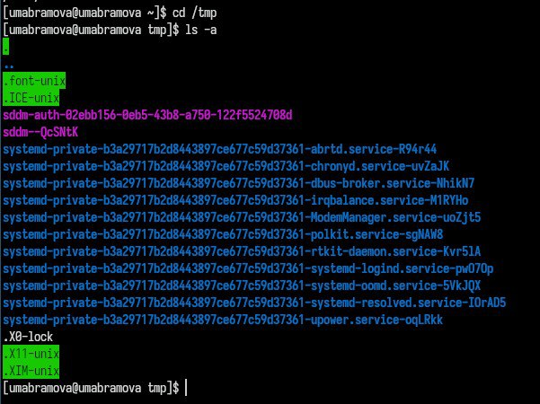

вывод содержимого каталога /tmp

## Содержание исследования

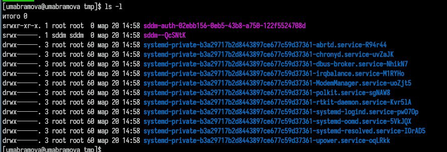

вывод содержимого каталога /tmp

## Содержание исследования

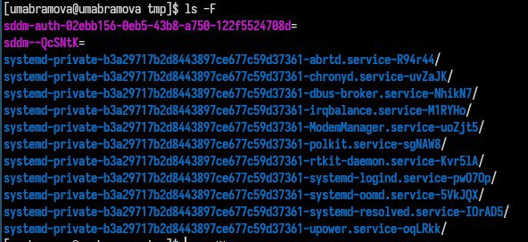

вывод содержимого каталога /tmp

## Содержание исследования

Таким образом, ls -a позволяет отобразить имена скрытых файлов, ls -l выводит на экран подробную информацию о файлах и каталогах, ls -F позволяет получить информацию о типах файлов (каталог, исполняемый файл, ссылка).

## Содержание исследования

Определяю, есть ли в каталоге /var/spool подкаталог с именем cron (рис.5).

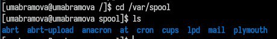

вывод содержимого каталога /var/spool

## Содержание исследования

Перехожу в свой домашний каталог и вывожу на экран его содержимое с помощью команды ls. Далее, используя ту же команду, но уже с опцией -l, определяю, кто является владельцем файлов и подкаталогов (рис.6).

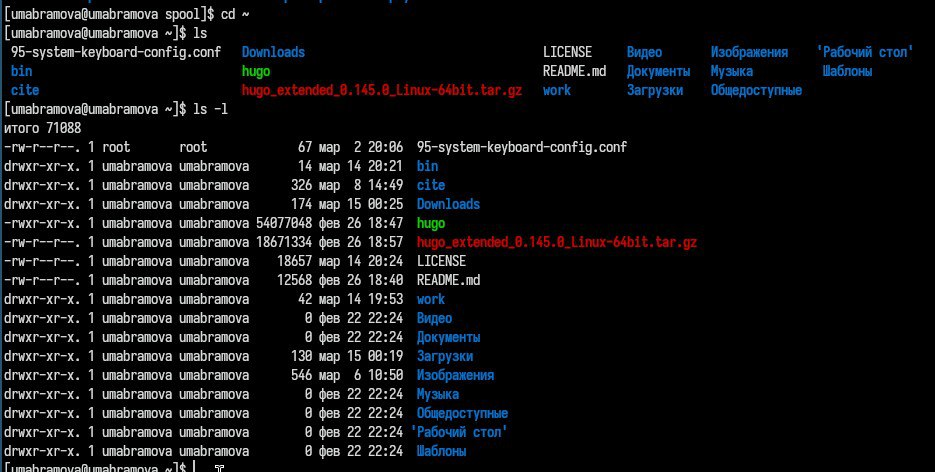

использование команды ls с опцией -l

## Содержание исследования

В домашнем каталоге создаю новый каталог с именем newdir. Далее создаю в каталоге ~/newdir новый каталог с именем morefun (рис.7).

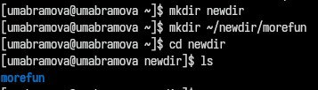

использование команды mkdir

## Содержание исследования

В домашнем каталоге создаю одной командой три новых каталога с именами letters, memos, misk (рис.8).

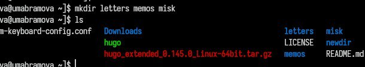

использование команды mkdir

## Содержание исследования

После чего удаляю эти каталоги одной командой (рис.9).

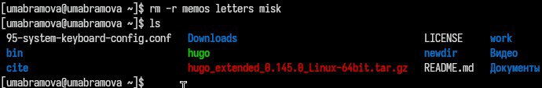

## Содержание исследования

Удаляю ранее созданный каталог ~/newdir командой rm. Проверяю, был ли каталог удалён (рис.10).

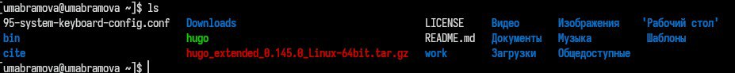

использование команды ls

## Содержание исследования

С помощью команды man определяю, какую опцию команды ls нужно использовать для просмотра содержимое не только указанного каталога, но и подкаталогов, входящих в него (рис.11).

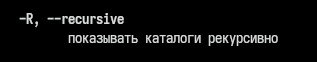

использование команды man

## Содержание исследования

Использую команду man для просмотра описания следующих команд: cd, pwd, mkdir, rmdir, rm (рис.13,14,15,16,17).

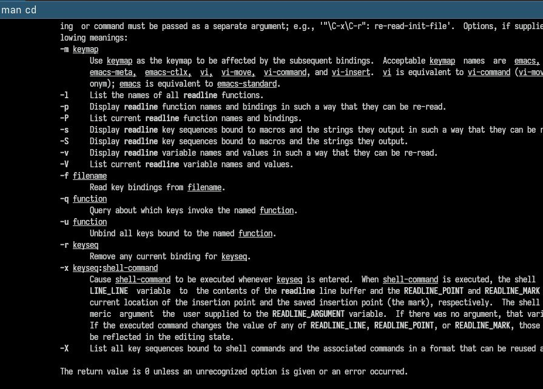

использование команды man

## Содержание исследования

Основные опции команды cd:

- -L - переходить по символическим ссылкам, данное поведение используется по умолчанию.
- -P - разыменовывать символические ссылки. В данном случае, если осуществляется переход на символическую ссылку, которая указывает на директорию, то в результате команда cd изменит текущую рабочую директорию на директорию, указанную в качестве параметра (то есть ссылка будет разыменована).
- -e - выдача ошибки, если папку, в которую нужно перейти, не удалось найти

## Содержание исследования

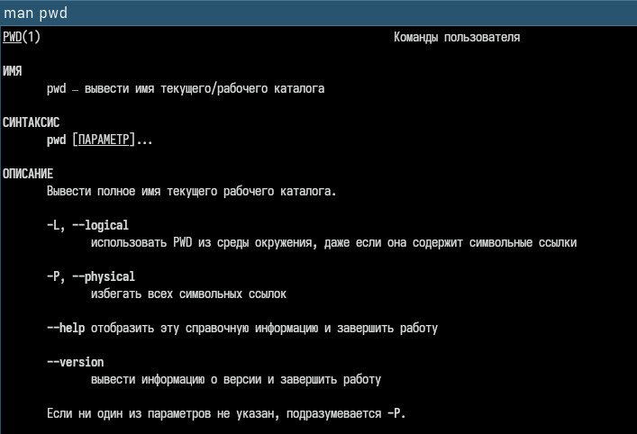

использование команды man

## Содержание исследования

Основные опции команды pwd:

- -L (или –logical) - не разыменовывает символические ссылки, то есть, если путь содержит символические ссылки, то выводит их без преобразования в исходный путь.
- -P (или –physical) - преобразовывает символические ссылки в исходные имена, то есть, если путь содержит символические ссылки, то они будут преобразованы в названия исходных директорий, на которые они указывают.
- -help - отображает справку по команде pwd.
- -version - отображает версию утилиты pwd.

## Содержание исследования

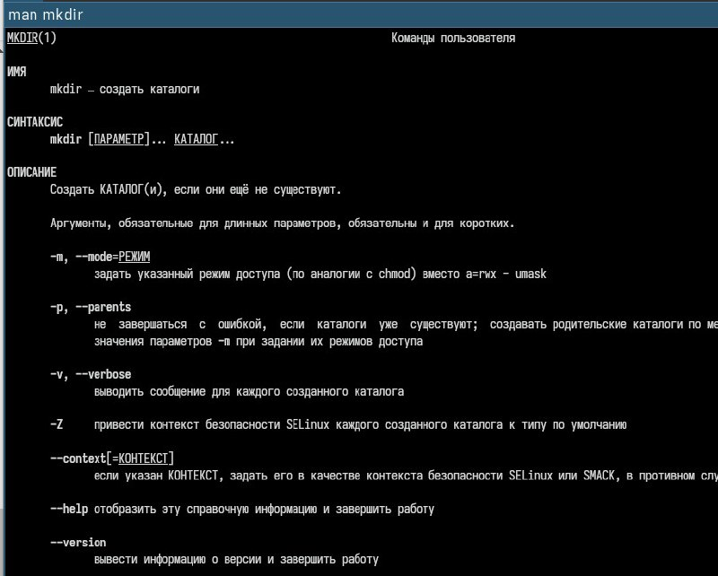

использование команды man

## Содержание исследования

Основные опции команды mkdir:

- -m или –mode - устанавливает права доступа для создаваемой директории.
- -p или –parents - создать все директории, которые указаны внутри пути. Если какая-либо директория существует, то предупреждение об этом не выводится.
- -v или –verbose - выводить сообщение о каждой создаваемой директории.
- -Z - установить контекст SELinux для создаваемой директории по умолчанию.
- –context[=CTX] - установить контекст SELinux для создаваемой директории в значение CTX
- –help - показать справку по команде mkdir
- –version - показать версию утилиты mkdir

## Содержание исследования

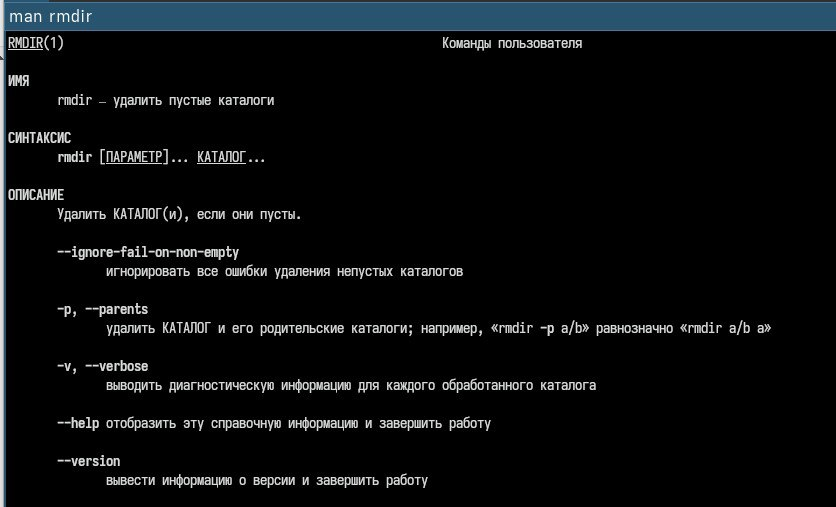

использование команды man

## Содержание исследования

Основные опции команды rmdir:  
- -ignore-fail-on-non-empty - не выводит сообщение об ошибке при попытке удаления непустого каталога. - -p - удаляет каталог и его родителя из иерархии. - -v - выводит подробную информацию о выполнении команды. - -help - выводит текст справки. - -version - указывает версию команды.

## Содержание исследования

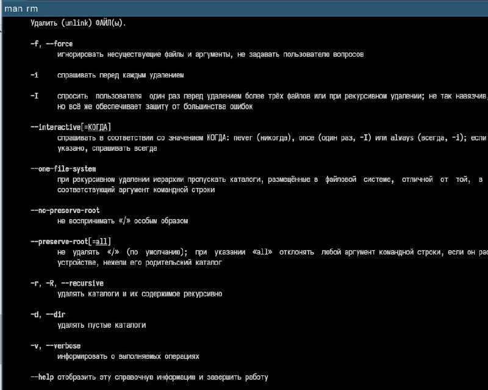

использование команды man

## Содержание исследования

Основные опции команды rm:

- -i - запрашивает подтверждение перед удалением каждого файла.
- -f - игнорирует ошибки и не запрашивает подтверждение удаления файлов.
- -r - рекурсивно удаляет каталоги и их содержимое.
- -d - удаляет пустой каталог.
- -v - показывает, что делает команда.

## Содержание исследования

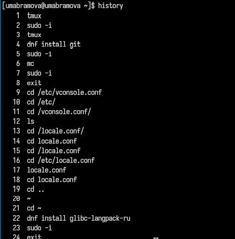

использование команды history

## Содержание исследования

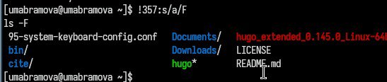

выполнение модификации

## Результаты

- В результате я приобрела практические навыки взаимодействия с системой посредством командной строки.

## Итоговый слайд

- Чем больше вы практикуетесь и пробуете новое, тем больше и чаще вы будете получать знаний и опыта в разных сферах.